# FIFA player Visualization

GIANNCARLO MARTINEZ

2025-09-17

```r
library(tidyr)
library(dplyr)
library(ggplot2)
```

## Question One

The graph shows the average FIFA player rating by age.

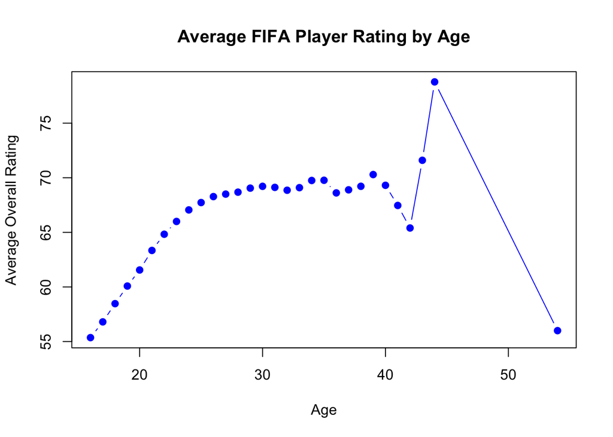

```r
#load CSV
fifa <- read.csv("~/Desktop/fifa_database.csv")

#Do my basic Data aggregating
overall_by_age <- aggregate(fifa$overall ~ fifa$age, data = fifa, mean, na.rm = TRUE)
names(overall_by_age) <- c("Age", "AverageOverall")

#plotting
plot(overall_by_age$Age, overall_by_age$AverageOverall,
     type = "b", col = "blue", pch = 19,
     xlab = "Age",
     ylab = "Average Overall Rating",
     main = "Average FIFA Player Rating by Age")
```

## Question Two

My hypothesis is that most players have an overall rating in the 60s with only a small group being elite in 80+ and a small group is low rated below 55. My histogram shows the mode distribution is around 65 to 70.

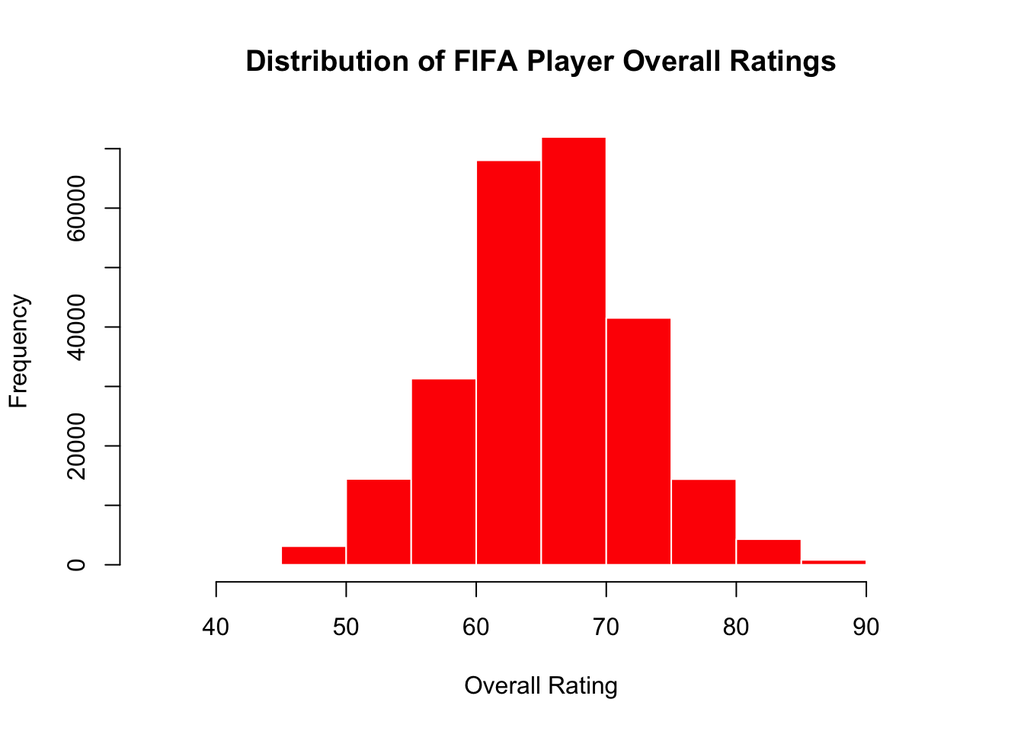

```r
#Set up statistic data
mean_overall <- mean(fifa$overall, na.rm = TRUE)
median_overall <- median(fifa$overall, na.rm = TRUE)
sd_overall <- sd(fifa$overall, na.rm = TRUE)

#plotting
hist(fifa$overall,
     main = "Distribution of FIFA Player Overall Ratings",
     xlab = "Overall Rating",
     col = "red",
     border = "white")
```

## Question Three

My statistical test and the scatter plot show how age is an important factor in a players overall performance rating, matching the expected career progression of professional soccer players in the game. FIFA is very good because is a great simulator to play real soccer.

```r
# Filtering data
filtered_data <- fifa[fifa$age >= 18 & fifa$age <= 35, ]

# numeric values
filtered_data$age <- as.numeric(as.character(filtered_data$age))
filtered_data$overall <- as.numeric(as.character(filtered_data$overall))

# Aggregating: average overall rating by age
overall_by_age <- aggregate(filtered_data$overall ~ filtered_data$age, data = filtered_data, mean)
names(overall_by_age) <- c("Age", "AverageOverall")

# Correlation test
correlation <- cor.test(overall_by_age$Age, overall_by_age$AverageOverall)

# Linear model
LinearModel <- lm(AverageOverall ~ Age, data = overall_by_age)
summary(LinearModel)
```

```
##
## Call:
## lm(formula = AverageOverall ~ Age, data = overall_by_age)
##
## Residuals:
##     Min      1Q  Median      3Q     Max
## -3.1601 -1.2830  0.2355  1.3602  1.9797
##
## Coefficients:
##             Estimate Std. Error t value Pr(>|t|)
## (Intercept) 51.04672    2.01528   25.33 2.44e-14 ***
## Age          0.58811    0.07463    7.88 6.74e-07 ***
## ---
## Signif. codes:  0 '***' 0.001 '**' 0.01 '*' 0.05 '.' 0.1 ' ' 1
##
## Residual standard error: 1.643 on 16 degrees of freedom
## Multiple R-squared:  0.7951, Adjusted R-squared:  0.7823
## F-statistic:  62.1 on 1 and 16 DF,  p-value: 6.741e-07
```

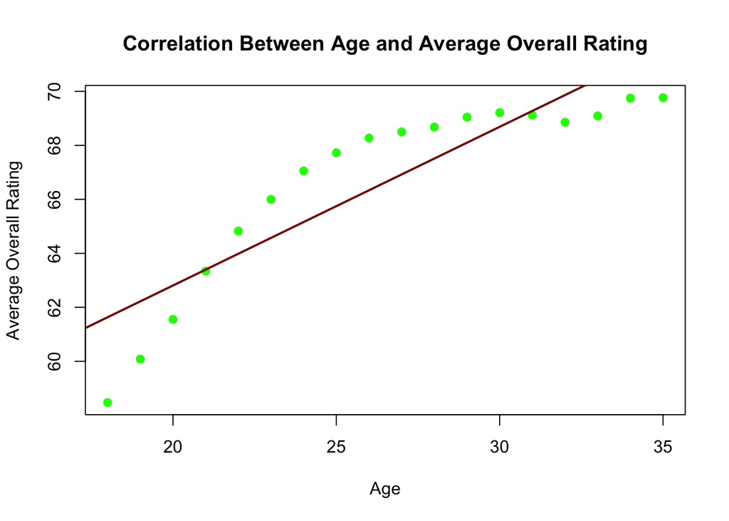

```r
# Scatter plot with regression line
plot(overall_by_age$Age, overall_by_age$AverageOverall,
     main = "Correlation Between Age and Average Overall Rating",
     xlab = "Age",
     ylab = "Average Overall Rating",
     pch = 19, col = "green")
abline(LinearModel, col = "dark red", lwd = 2)
```

## Question four

In the histogram of player market value is in euros shows a right skewed distribution. The majoriry of the players are clustered on the lower end of the value range, the majority of the players are worth under 20 million of euros. It is moving to the right the frequency of players decrease sharply indicating the high value players are very rare.

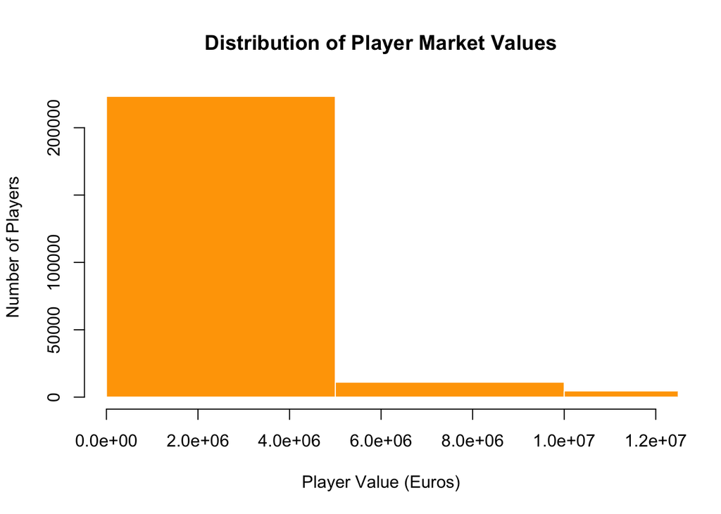

```r
# numeric value
fifa$value_eur <- as.numeric(as.character(fifa$value_eur))

# Plot histogram of player market values
hist(fifa$value_eur,
     breaks = 50,
     col = "orange",
     border = "white",
     main = "Distribution of Player Market Values",
     xlab = "Player Value (Euros)",
     ylab = "Number of Players",
     xlim = c(0, quantile(fifa$value_eur, 0.95, na.rm = TRUE)))
```

## Question five

I show with my code the player position forward vs midfielder is related to overall rating. it show how significant the posotion are the diference and have a similar distribution.

```r
# Filter dataset
fifa_groups <- fifa[fifa$player_positions %in% c("ST", "CM"), ]

# Divide into two groups
forwards <- fifa_groups[fifa_groups$player_positions == "ST", "overall"]
midfielders <- fifa_groups[fifa_groups$player_positions == "CM", "overall"]

# Perform independent t-test
t_test_result <- t.test(forwards, midfielders, var.equal = FALSE)

print(t_test_result)
```

```
##
##  Welch Two Sample t-test
##
## data:  forwards and midfielders
## t = 35.959, df = 16031, p-value < 2.2e-16
## alternative hypothesis: true difference in means is not equal to 0
## 95 percent confidence interval:
##  3.170832 3.536445
## sample estimates:
## mean of x mean of y
##  65.84148  62.48784
```